# 4-KNN,Regression,Classification Metrics, Clustering slides

## kmeans, k-Nearest-Neighbor,Regression, Classification Metrics, Clustering

## KMeans Clustering

It is an Unsupervised learning technique

‘K’ in K-Means is the number of clusters

The clusters are often unknown since this is used with Unsupervised learning.

It is typically used for scenarios like understanding the population demomgraphics, market segmentation, social media trends, anomaly detection, etc. where the clusters are unknown to begin with.

In training phase of K-Means, K observations are selected (known as centroids).

Each point in the vector space is assigned to a cluster represented by nearest (euclidean distance) centroid.

Once the clusters are formed, for each cluster the centroid is updated to the mean of all cluster members.

And the cluster formation restarts with new centroids. This repeats until the centroids themselves become mean of clusters,

> The prediction of a test observation is done based on nearest centroid.

```python
df = pd.read_csv('../data/loan_knn.csv')
```

```python
df.head()
```

|  | Gender | Age | Salary | Default |
| --- | --- | --- | --- | --- |
| 0 | M | 24 | 21730 | 0 |
| 1 | M | 40 | 22730 | 0 |
| 2 | F | 31 | 45730 | 0 |
| 3 | F | 32 | 59730 | 0 |
| 4 | M | 24 | 78730 | 0 |

```python
X = df.iloc[ : , -2:]
```

```python
X.head()
```

|  | Salary | Default |
| --- | --- | --- |
| 0 | 21730 | 0 |
| 1 | 22730 | 0 |
| 2 | 45730 | 0 |
| 3 | 59730 | 0 |
| 4 | 78730 | 0 |

```python
from sklearn.impute import SimpleImputer
from sklearn.preprocessing import OneHotEncoder
from sklearn.preprocessing import StandardScaler
from sklearn.compose import ColumnTransformer
from sklearn.pipeline import Pipeline
```

```python
transformer = Pipeline(steps=[
    ("missing_value", SimpleImputer(strategy="mean")),
    ("scaler", StandardScaler())
])
```

```python
preprocessor = ColumnTransformer(transformers=[
    ('transformer', transformer, [0,1])
])
```

```python
from sklearn.cluster import KMeans
```

### Elbow Plots: Determining Optimal K

When K increases, the centroids are closer to the clusters centroids.

The improvements will decline, at some point rapidly, creating the elbow shape.

```python
wcss = []
```

```python
for i in range(1, 11):
    kmeans = Pipeline(steps=[
            ('preprocess', preprocessor),
            ('kmeansa', KMeans(n_clusters=i))])
    kmeans.fit(X)
    wcss.append(kmeans.named_steps["kmeansa"].inertia_)
```

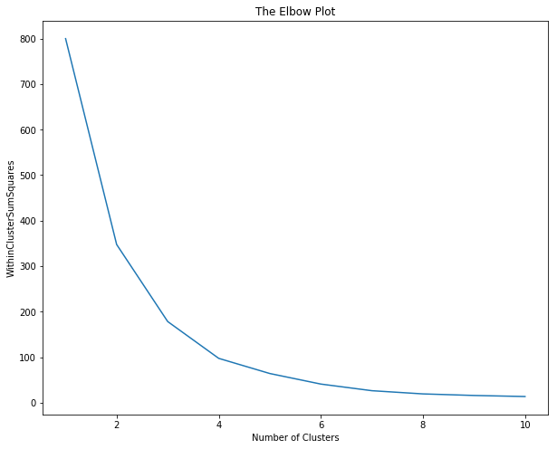

```python
plt.figure(figsize = (10, 8))
plt.plot(range(1, 11), wcss)
plt.title('The Elbow Plot')
plt.xlabel('Number of Clusters')
plt.ylabel('WithinClusterSumSquares')
plt.show()
```

```python
kmeans = Pipeline(steps=[
            ('preprocess', preprocessor),
            ('kmeansa', KMeans(n_clusters=5))])
kmeans.fit(X)
y_pred = kmeans.fit_predict(X)
```

```python
y_pred
```

```
array([4, 4, 4, 0, 0, 0, 0, 3, 4, 0, 0, 4, 0, 4, 0, 0, 2, 2, 2, 2, 2, 2,
       2, 2, 2, 2, 2, 2, 4, 4, 0, 3, 4, 4, 0, 4, 4, 4, 0, 4, 4, 4, 0, 4,
       0, 4, 0, 4, 3, 0, 4, 4, 0, 4, 0, 4, 4, 0, 4, 0, 4, 0, 0, 3, 0, 0,
       4, 0, 0, 0, 0, 4, 4, 0, 4, 1, 4, 4, 0, 4, 0, 4, 4, 0, 0, 3, 4, 0,
       0, 4, 0, 0, 4, 4, 0, 4, 4, 3, 0, 4, 0, 0, 0, 3, 4, 0, 4, 0, 0, 0,
       0, 0, 0, 4, 0, 0, 0, 4, 0, 0, 0, 0, 0, 4, 4, 0, 0, 4, 4, 0, 0, 4,
       0, 0, 4, 0, 0, 1, 0, 4, 0, 0, 0, 0, 4, 0, 1, 4, 0, 0, 4, 4, 0, 4,
       4, 4, 0, 0, 4, 3, 1, 0, 4, 4, 0, 0, 4, 0, 3, 4, 0, 0, 0, 4, 0, 4,
       4, 4, 4, 4, 4, 0, 3, 4, 0, 0, 0, 4, 0, 4, 0, 4, 4, 0, 0, 4, 0, 4,
       0, 4, 4, 0, 3, 0, 1, 4, 3, 0, 3, 4, 1, 3, 4, 0, 4, 1, 0, 0, 0, 3,
       0, 1, 3, 1, 0, 4, 3, 3, 0, 1, 3, 4, 1, 1, 0, 1, 0, 0, 0, 3, 3, 0,
       1, 1, 0, 3, 4, 3, 4, 1, 4, 4, 3, 3, 4, 1, 0, 0, 1, 3, 0, 3, 3, 0,
       1, 1, 0, 0, 3, 0, 0, 1, 2, 1, 2, 1, 0, 1, 2, 2, 1, 0, 1, 2, 0, 1,
       0, 3, 0, 1, 3, 1, 2, 0, 0, 0, 1, 1, 0, 3, 2, 1, 3, 1, 0, 4, 0, 1,
       3, 4, 0, 1, 4, 3, 0, 1, 1, 4, 2, 0, 3, 1, 4, 2, 3, 0, 0, 0, 3, 1,
       4, 3, 0, 0, 2, 4, 3, 0, 4, 3, 1, 0, 0, 2, 1, 0, 1, 1, 0, 0, 1, 0,
       1, 0, 1, 2, 1, 0, 1, 4, 3, 2, 2, 0, 1, 2, 2, 1, 0, 2, 2, 1, 0, 3,
       0, 2, 0, 4, 1, 2, 0, 2, 3, 2, 2, 2, 2, 0, 2, 2, 2, 2, 2, 2, 0, 2,
       2, 2, 4, 2], dtype=int32)
```

### Mr.k and His Neighborhood

- Hedonic Regressions can be used to break down compositions of baskets of items that are assembled of items
- Intsead of focusing on fitting a curve to a bag of attributes, it focuses on the components of the bag.

### `KNN` Development

#### Agorithm was introduced by Drs. Evelyn Fix and J. L. Hodges Jr,

- An unpublished technical report written for the U.S. Air Force School of Aviation Medicine. Fix and Hodges’ original research focused on splitting up classification problems into a few subproblems:
- Distributions F and G are completely known.
- Distributions F and G are completely known except for a few parameters.
- F and G are unknown, except possibly for the existence of densities.

Fix and Hodges pointed out if you know the distributions of two classifications or you know the distribution minus some parameters, you can easily back out useful solutions.

#### The Algorithm can take two forms, a regression to produce a value, or a classification.

KNN can be used for both classification and regression problems. The algorithm uses **feature similarity** to predict values of any new data points. This means that the new point is assigned a value based on how closely it resembles the points in the training set

#### Generic Steps

1. Distance to a new data point is calcualted in regards to the training data
2. The closest `k` data points are selected
3. The average of these data points is the final prediction

K-NN doesn’t have a training phase as such. But the prediction of a test observation is done based on the K-Nearest (often euclidean distance) Neighbours (observations) based on weighted averages/votes.

### Distance Methods - *As the Crow Flies*

Calculating the distance between points can be done in may ways:

- generally are: geometric, computaional, and statistical

### Choosing the Optimal `k`

- The predicted value will change according to the value of `k` that is chosen.
- Use an error calculation to choose the optimum k in order to trian the model
- **Elbow Curves**: are plots of the validation error inside knn models, they will show you graphically where the optimum `k` will be

## KNN Regressions

```python
import pandas as pd
import numpy as np
```

```python
df = pd.read_csv("../data/50_Startups.csv")
```

```python
df.head()
```

|  | R&D Spend | Administration | Marketing Spend | State | Profit |
| --- | --- | --- | --- | --- | --- |
| 0 | 165349.20 | 136897.80 | 471784.10 | New York | 192261.83 |
| 1 | 162597.70 | 151377.59 | 443898.53 | California | 191792.06 |
| 2 | 153441.51 | 101145.55 | 407934.54 | Florida | 191050.39 |
| 3 | 144372.41 | 118671.85 | 383199.62 | New York | 182901.99 |
| 4 | 142107.34 | 91391.77 | 366168.42 | Florida | 166187.94 |

```python
X = df.drop('Profit', axis=1)
y = df['Profit']
```

```python
categorical_features = ['State']
numeric_features = ['R&D Spend', 'Administration', 'Marketing Spend']
```

```python
from sklearn.impute import SimpleImputer
from sklearn.preprocessing import OneHotEncoder
from sklearn.preprocessing import StandardScaler
from sklearn.compose import ColumnTransformer
from sklearn.pipeline import Pipeline
```

```python
numeric_transformer = Pipeline(steps=[
        ('imputer', SimpleImputer(missing_values=np.nan, strategy='median')),
        ('scaler', StandardScaler())])
```

```python
categorical_transformer = Pipeline(steps=[
        ('imputer', SimpleImputer(missing_values=np.nan, strategy='most_frequent')),
        ('onehot' , OneHotEncoder(sparse=False))])
```

```python
preprocessor = ColumnTransformer(
    transformers=[
        ('num', numeric_transformer, numeric_features),
        ('cat', categorical_transformer, categorical_features)])
```

```python
from sklearn.neighbors import KNeighborsRegressor
```

```python
model = Pipeline(steps= [ ("preprocess", preprocessor), ("knn_model", KNeighborsRegressor(n_neighbors=7))])
```

```python
from sklearn.model_selection import train_test_split
X_train, X_test, y_train, y_test = train_test_split(X, y, test_size = .20, random_state = 123)
```

```python
model.fit(X_train, y_train)
```

```
Pipeline(memory=None,
     steps=[('preprocess', ColumnTransformer(n_jobs=None, remainder='drop', sparse_threshold=0.3,
         transformer_weights=None,
         transformers=[('num', Pipeline(memory=None,
     steps=[('imputer', SimpleImputer(copy=True, fill_value=None, missing_values=nan,
       strategy='median', verbose...wski',
          metric_params=None, n_jobs=None, n_neighbors=7, p=2,
          weights='uniform'))])
```

```python
y_pred = model.predict(X_test)
y_pred
```

```
array([121646.82      , 125833.84857143,  97771.95714286,  93192.88285714,
       126181.80857143, 161967.93857143,  85103.36571429, 119563.84      ,
       105691.52428571, 134695.14      ])
```

```python
from sklearn.metrics import mean_squared_error
np.sqrt(mean_squared_error(y_test, y_pred))
```

```
20898.913739388816
```

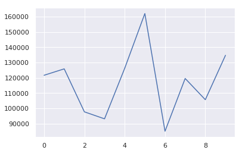

```python
%matplotlib inline
import matplotlib.pyplot as plt
import seaborn as sns; sns.set()  # for plot styling

plt.plot(y_pred)
```

## KNN Classifier Model

```python
df = pd.read_csv('../data/loan_knn.csv')
```

### Run a Logistic First

```python
df.head()
```

|  | Gender | Age | Salary | Default |
| --- | --- | --- | --- | --- |
| 0 | M | 24 | 21730 | 0 |
| 1 | M | 40 | 22730 | 0 |
| 2 | F | 31 | 45730 | 0 |
| 3 | F | 32 | 59730 | 0 |
| 4 | M | 24 | 78730 | 0 |

```python
df.Default.value_counts()
```

```
0    257
1    143
Name: Default, dtype: int64
```

### Preprocess your data

```python
X = df[["Gender", "Age", "Salary"]]
```

```python
y = df["Default"]
```

### Create your impute variables

```python
numerical_variable = ["Age", "Salary"]
categorical_variable = ["Gender"]
```

```python
from sklearn.impute import SimpleImputer
from sklearn.preprocessing import OneHotEncoder
from sklearn.preprocessing import StandardScaler
from sklearn.compose import ColumnTransformer
from sklearn.pipeline import Pipeline
```

### Create the Transformers

```python
numerical_transformer = Pipeline(steps=[
    ("missing_value", SimpleImputer(strategy="mean")),
    ("scaling", StandardScaler())
])
```

```python
categorical_transformer = Pipeline(steps=[
    ("missing_value", SimpleImputer(strategy="most_frequent")),
    ("encoding", OneHotEncoder(sparse=False))
])
```

```python
preprocessor = ColumnTransformer(transformers=[
    ('munerical_transformer', numerical_transformer, numerical_variable),
    ('categorical_transformer', categorical_transformer, categorical_variable)
])
```

### Create your Model Pipeline for the Logistic Regression

```python
from sklearn.linear_model import LogisticRegression
```

```python
model = Pipeline(steps=[
    ('preprocess', preprocessor),
    ('logistic_model', LogisticRegression())
])
```

### Split the data for triaining and testing

```python
from sklearn.model_selection import train_test_split
```

```python
X_train, X_test, y_train, y_test = train_test_split(X, y, test_size = 0.2, random_state = 123)
```

```python
model.fit(X_train, y_train)
```

```
Pipeline(memory=None,
     steps=[('preprocess', ColumnTransformer(n_jobs=None, remainder='drop', sparse_threshold=0.3,
         transformer_weights=None,
         transformers=[('munerical_transformer', Pipeline(memory=None,
     steps=[('missing_value', SimpleImputer(copy=True, fill_value=None, missing_values=nan, strategy=...penalty='l2', random_state=None, solver='warn',
          tol=0.0001, verbose=0, warm_start=False))])
```

```python
y_pred = model.predict(X_test)
y_pred
```

```
array([1, 0, 0, 0, 0, 0, 0, 1, 1, 0, 0, 0, 1, 0, 0, 1, 0, 0, 0, 0, 0, 0,
       0, 0, 0, 0, 0, 1, 0, 0, 0, 0, 1, 0, 0, 1, 0, 0, 0, 1, 0, 0, 0, 0,
       1, 0, 0, 1, 0, 0, 0, 0, 1, 1, 1, 0, 0, 1, 0, 0, 0, 0, 0, 1, 0, 1,
       0, 1, 0, 0, 0, 1, 0, 0, 1, 0, 1, 0, 1, 1])
```

```python
y_pred_prob = model.predict_proba(X_test)[: , 1]
y_pred_prob
```

```
array([0.57617337, 0.43284375, 0.31057969, 0.01476435, 0.23199125,
       0.1574718 , 0.02592149, 0.95867151, 0.56477022, 0.2370814 ,
       0.06278996, 0.44325264, 0.76138825, 0.0203524 , 0.08631156,
       0.8990086 , 0.03755598, 0.0815322 , 0.06613946, 0.14202835,
       0.04641536, 0.18338286, 0.00582901, 0.12935613, 0.08554745,
       0.39925836, 0.01765499, 0.98669763, 0.22495711, 0.4812243 ,
       0.43863311, 0.15085584, 0.55019492, 0.0019183 , 0.23631302,
       0.7469413 , 0.23176486, 0.43953213, 0.41514813, 0.50324258,
       0.28546283, 0.15948415, 0.27739297, 0.07383127, 0.97752535,
       0.03281029, 0.40814699, 0.92021491, 0.48393012, 0.29742431,
       0.49404017, 0.037622  , 0.95487694, 0.66821944, 0.97700218,
       0.31317808, 0.02293125, 0.7123248 , 0.02783042, 0.00567663,
       0.25009461, 0.2654585 , 0.32392721, 0.99133655, 0.41063316,
       0.86948314, 0.26474734, 0.98881667, 0.07711685, 0.00546957,
       0.0021291 , 0.85320007, 0.17071126, 0.08125927, 0.98203975,
       0.02678949, 0.77059112, 0.42252171, 0.55897376, 0.56224109])
```

### Test the Models Accuracy

```python
from sklearn.metrics import accuracy_score
```

```python
accuracy_score(y_test, y_pred)
```

```
0.8375
```

### Plot the ROC and AUC Scores

```python
import matplotlib.pyplot as plt
%matplotlib inline
```

```python
from sklearn.metrics import roc_curve, roc_auc_score

fpr, tpr, threshold = roc_curve(y_test, y_pred_prob)
auc_score = roc_auc_score(y_test, y_pred_prob)
```

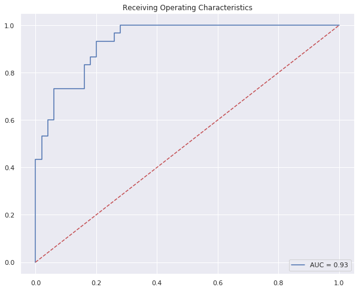

```python
plt.figure(figsize=(10,8))
plt.title('Receiving Operating Characteristics')
plt.plot(fpr, tpr, 'b', label = 'AUC = %0.2f'%auc_score)
plt.legend(loc = 'lower right')
plt.plot([0,1], [0,1], 'r--')
```

[figure not shown]

```python
plt.xlim([-0.1,1.1])
plt.ylim([-0.1,1.1])
plt.xlabel('False Positive Rate')
plt.ylabel('True Positive Rate')
plt.show()
```

### Plot the Confusion Matrix

```python
from sklearn.metrics import confusion_matrix
cm = confusion_matrix(y_test, y_pred)
cm
```

```
array([[47,  3],
       [10, 20]])
```

```python
import itertools
def plot_confusion_matrix(cm, classes,
                          normalize=False,
                          title='Confusion matrix',
                          cmap=plt.cm.Blues):
    """
    This function prints and plots the confusion matrix.
    Normalization can be applied by setting `normalize=True`.
    """
    if normalize:
        cm = cm.astype('float') / cm.sum(axis=1)[:, np.newaxis]
        print("Normalized confusion matrix")
    else:
        print('Confusion matrix, without normalization')

    print(cm)

    plt.imshow(cm, interpolation='nearest', cmap=cmap)
    plt.title(title)
    plt.colorbar()
    tick_marks = np.arange(len(classes))
    plt.xticks(tick_marks, classes, rotation=45)
    plt.yticks(tick_marks, classes)

    fmt = '.2f' if normalize else 'd'
    thresh = cm.max() / 2.
    for i, j in itertools.product(range(cm.shape[0]), range(cm.shape[1])):
        plt.text(j, i, format(cm[i, j], fmt),
                 horizontalalignment="center",
                 color="white" if cm[i, j] > thresh else "black")

    plt.ylabel('True label')
    plt.xlabel('Predicted label')
    plt.tight_layout()
```

```
Confusion matrix, without normalization
[[47  3]
 [10 20]]
```

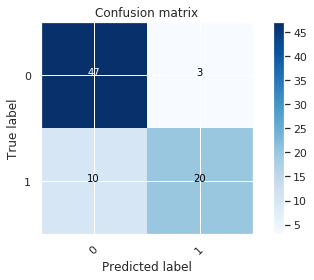

```python
plot_confusion_matrix(cm, df.Default.unique())
```

```python
df.Default.unique()
```

```
array([0, 1])
```

### KNN Classifier

- The Classfier is simple to implement and will output the category it believes according the majority vote

```python
df.head()
```

|  | Gender | Age | Salary | Default |
| --- | --- | --- | --- | --- |
| 0 | M | 24 | 21730 | 0 |
| 1 | M | 40 | 22730 | 0 |
| 2 | F | 31 | 45730 | 0 |
| 3 | F | 32 | 59730 | 0 |
| 4 | M | 24 | 78730 | 0 |

### Assign the `x` and `y` values

```python
X = df[["Gender", "Age", "Salary"]]
```

```python
y = df["Default"]
```

```python
numerical_variable = ["Age", "Salary"]
categorical_variable = ["Gender"]
```

### Import your toolset

```python
from sklearn.impute import SimpleImputer
from sklearn.preprocessing import OneHotEncoder
from sklearn.preprocessing import StandardScaler
from sklearn.compose import ColumnTransformer
from sklearn.pipeline import Pipeline
```

```python
numerical_transformer = Pipeline(steps=[
    ("missing_value", SimpleImputer(strategy="mean")),
    ("scaling", StandardScaler())
])
```

```python
categorical_transformer = Pipeline(steps=[
    ("missing_value", SimpleImputer(strategy="most_frequent")),
    ("encoding", OneHotEncoder(sparse=False))
])
```

```python
preprocessor = ColumnTransformer(transformers=[
    ('munerical_transformer', numerical_transformer, numerical_variable),
    ('categorical_transformer', categorical_transformer, categorical_variable)
])
```

### Import the KNeighborsClassifer and build your model pipeline

```python
from sklearn.neighbors import KNeighborsClassifier
```

```python
model = Pipeline(steps=[
    ('preprocess', preprocessor),
    ('knn_model', KNeighborsClassifier(n_neighbors=5))
])
```

### Split the Dataset into trainging and test sets; fit your models

```python
from sklearn.model_selection import train_test_split
```

```python
X_train, X_test, y_train, y_test = train_test_split(X, y, test_size = 0.2, random_state = 123)
```

```python
model.fit(X_train, y_train)
```

```
Pipeline(memory=None,
     steps=[('preprocess', ColumnTransformer(n_jobs=None, remainder='drop', sparse_threshold=0.3,
         transformer_weights=None,
         transformers=[('munerical_transformer', Pipeline(memory=None,
     steps=[('missing_value', SimpleImputer(copy=True, fill_value=None, missing_values=nan, strategy=...ki',
           metric_params=None, n_jobs=None, n_neighbors=5, p=2,
           weights='uniform'))])
```

```python
y_pred = model.predict(X_test)
y_pred
```

```
array([1, 1, 0, 0, 0, 0, 0, 1, 0, 1, 0, 0, 1, 0, 0, 1, 0, 0, 0, 0, 0, 0,
       0, 1, 0, 1, 0, 1, 0, 0, 1, 0, 1, 0, 0, 1, 0, 0, 1, 0, 0, 0, 0, 0,
       1, 0, 0, 1, 1, 0, 1, 0, 1, 1, 1, 1, 0, 1, 0, 0, 1, 1, 1, 1, 1, 1,
       0, 1, 0, 0, 0, 1, 0, 0, 1, 0, 1, 1, 0, 1])
```

```python
y_pred_prob = model.predict_proba(X_test)[: , 1]
y_pred_prob
```

```
array([0.8, 1. , 0. , 0. , 0. , 0. , 0. , 0.8, 0.2, 0.8, 0. , 0.2, 0.6,
       0. , 0. , 0.8, 0. , 0. , 0. , 0. , 0. , 0. , 0. , 0.8, 0. , 1. ,
       0. , 0.8, 0. , 0.2, 1. , 0. , 1. , 0. , 0. , 1. , 0. , 0. , 1. ,
       0.2, 0.2, 0. , 0.2, 0. , 0.8, 0. , 0. , 0.8, 1. , 0. , 1. , 0. ,
       0.8, 1. , 0.8, 1. , 0. , 1. , 0. , 0. , 1. , 1. , 0.8, 0.8, 0.6,
       0.8, 0.2, 0.8, 0. , 0. , 0. , 0.8, 0. , 0. , 0.8, 0. , 0.8, 1. ,
       0. , 1. ])
```

### Test the Models accuracy and plot the AUC and ROC

```python
from sklearn.metrics import accuracy_score
```

```python
accuracy_score(y_test, y_pred)
```

```
0.875
```

```python
import matplotlib.pyplot as plt
%matplotlib inline
```

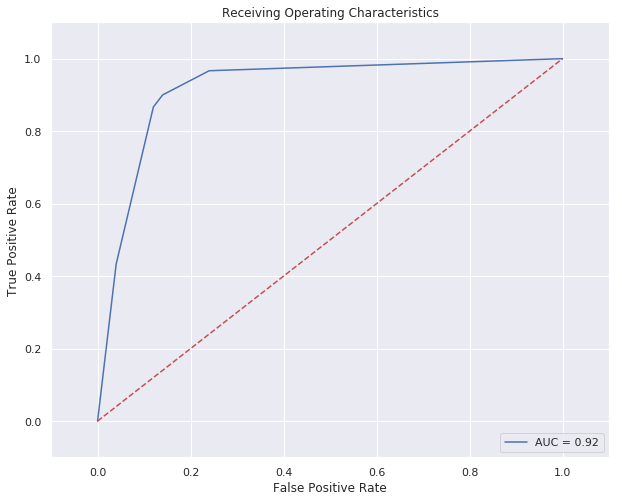

```python
from sklearn.metrics import roc_curve, roc_auc_score

fpr, tpr, threshold = roc_curve(y_test, y_pred_prob)
auc_score = roc_auc_score(y_test, y_pred_prob)

plt.figure(figsize=(10,8))
plt.title('Receiving Operating Characteristics')
plt.plot(fpr, tpr, 'b', label = 'AUC = %0.2f'%auc_score)
plt.legend(loc = 'lower right')
plt.plot([0,1], [0,1], 'r--')
plt.xlim([-0.1,1.1])
plt.ylim([-0.1,1.1])
plt.xlabel('False Positive Rate')
plt.ylabel('True Positive Rate')
plt.show()
```

### Plot and Print the Confusion Matrix

```python
from sklearn.metrics import confusion_matrix
cm = confusion_matrix(y_test, y_pred)
cm
```

```
array([[43,  7],
       [ 3, 27]])
```

```python
import itertools
def plot_confusion_matrix(cm, classes,
                          normalize=False,
                          title='Confusion matrix',
                          cmap=plt.cm.Blues):
    """
    This function prints and plots the confusion matrix.
    Normalization can be applied by setting `normalize=True`.
    """
    if normalize:
        cm = cm.astype('float') / cm.sum(axis=1)[:, np.newaxis]
        print("Normalized confusion matrix")
    else:
        print('Confusion matrix, without normalization')

    print(cm)

    plt.imshow(cm, interpolation='nearest', cmap=cmap)
    plt.title(title)
    plt.colorbar()
    tick_marks = np.arange(len(classes))
    plt.xticks(tick_marks, classes, rotation=45)
    plt.yticks(tick_marks, classes)

    fmt = '.2f' if normalize else 'd'
    thresh = cm.max() / 2.
    for i, j in itertools.product(range(cm.shape[0]), range(cm.shape[1])):
        plt.text(j, i, format(cm[i, j], fmt),
                 horizontalalignment="center",
                 color="white" if cm[i, j] > thresh else "black")

    plt.ylabel('True label')
    plt.xlabel('Predicted label')
    plt.tight_layout()
```

```
Confusion matrix, without normalization
[[43  7]
 [ 3 27]]
```

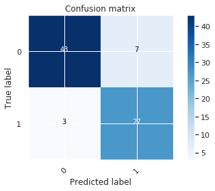

```python
plot_confusion_matrix(cm, df.Default.unique())
```

### Heirarchical Clustering

Hierarchical clustering is a type of unsupervised machine learning algorithm used to cluster unlabeled data points.

Like K-means clustering, hierarchical clustering also groups together the data points with similar characteristics. In some cases the result of hierarchical and K-Means clustering can be similar

### Theory of Hierarchical Clustering

There are two types of hierarchical clustering: Agglomerative and Divisive. In the former, data points are clustered using a bottom-up approach starting with individual data points, while in the latter top-down approach is followed where all the data points are treated as one big cluster and the clustering process involves dividing the one big cluster into several small clusters.

### Steps

1. At the start, treat each data point as one cluster. Therefore, the number of clusters at the start will be K, while K is an integer representing the number of data points.
2. Form a cluster by joining the two closest data points resulting in K-1 clusters.
3. Form more clusters by joining the two closest clusters resulting in K-2 clusters.
4. Repeat the above three steps until one big cluster is formed.
5. Once single cluster is formed, **dendrograms** are used to divide into multiple clusters depending upon the problem.

### Distance Meaures

Similar methods to KNN:

- Distance itself can be Euclidean or Manhattan distance.

Following are some of the options to measure distance between two clusters:

```
Measure the distance between the closes points of two clusters.
Measure the distance between the farthest points of two clusters.
Measure the distance between the centroids of two clusters.
Measure the distance between all possible combination of points between the two clusters and take the mean.
```